# Practicum1

Nishit

February 7, 2018

Q-1 -Download the dataset as follows based on url given

```r
# Q-1 -Download the dataset as follows based on url given#

dataurl <- "https://archive.ics.uci.edu/ml/machine-learning-databases/glass/glass.data"
download.file(url = dataurl, destfile = "glass.data")
glass_df <- read.csv("glass.data", header = FALSE)
```

Q-2 Exploring the dataset to get familiar with

```r
str(glass_df)
```

```
## 'data.frame':    214 obs. of  11 variables:
##  $ V1 : int  1 2 3 4 5 6 7 8 9 10 ...
##  $ V2 : num  1.52 1.52 1.52 1.52 1.52 ...
##  $ V3 : num  13.6 13.9 13.5 13.2 13.3 ...
##  $ V4 : num  4.49 3.6 3.55 3.69 3.62 3.61 3.6 3.61 3.58 3.6 ...
##  $ V5 : num  1.1 1.36 1.54 1.29 1.24 1.62 1.14 1.05 1.37 1.36 ...
##  $ V6 : num  71.8 72.7 73 72.6 73.1 ...
##  $ V7 : num  0.06 0.48 0.39 0.57 0.55 0.64 0.58 0.57 0.56 0.57 ...
##  $ V8 : num  8.75 7.83 7.78 8.22 8.07 8.07 8.17 8.24 8.3 8.4 ...
##  $ V9 : num  0 0 0 0 0 0 0 0 0 0 ...
##  $ V10: num  0 0 0 0 0 0.26 0 0 0 0.11 ...
##  $ V11: int  1 1 1 1 1 1 1 1 1 1 ...
```

```r
summary(glass_df)
```

```
##        V1               V2              V3              V4
##  Min.   :  1.00   Min.   :1.511   Min.   :10.73   Min.   :0.000
##  1st Qu.: 54.25   1st Qu.:1.517   1st Qu.:12.91   1st Qu.:2.115
##  Median :107.50   Median :1.518   Median :13.30   Median :3.480
##  Mean   :107.50   Mean   :1.518   Mean   :13.41   Mean   :2.685
##  3rd Qu.:160.75   3rd Qu.:1.519   3rd Qu.:13.82   3rd Qu.:3.600
##  Max.   :214.00   Max.   :1.534   Max.   :17.38   Max.   :4.490
##        V5              V6              V7               V8
##  Min.   :0.290   Min.   :69.81   Min.   :0.0000   Min.   : 5.430
##  1st Qu.:1.190   1st Qu.:72.28   1st Qu.:0.1225   1st Qu.: 8.240
##  Median :1.360   Median :72.79   Median :0.5550   Median : 8.600
##  Mean   :1.445   Mean   :72.65   Mean   :0.4971   Mean   : 8.957
##  3rd Qu.:1.630   3rd Qu.:73.09   3rd Qu.:0.6100   3rd Qu.: 9.172
##  Max.   :3.500   Max.   :75.41   Max.   :6.2100   Max.   :16.190
##        V9             V10               V11
##  Min.   :0.000   Min.   :0.00000   Min.   :1.00
##  1st Qu.:0.000   1st Qu.:0.00000   1st Qu.:1.00
##  Median :0.000   Median :0.00000   Median :2.00
##  Mean   :0.175   Mean   :0.05701   Mean   :2.78
##  3rd Qu.:0.000   3rd Qu.:0.10000   3rd Qu.:3.00
##  Max.   :3.150   Max.   :0.51000   Max.   :7.00
```

```r
#Adding column names to the glass dataframe#

colnames(glass_df) <- c("Id","RI","Na","Mg","Al","Si","K","Ca","Ma","Fe","Type of glass")
glass_df<-data.frame(glass_df)
View(glass_df)


attach(glass_df)
```

Q-3 creating a simple histogram of the Na column and overlaying a curve.

The data is pretty much normally distributed and K-NN is a non-parametric method.Nonparametric methods don’t have fixed numbers of parameters or estimates of parameters in the model. The reason why kNN is non-parametric is the model parameters actually grows with the training set - you can image each training instance as a “parameter” in the model, because they’re the things you use during prediction. The instance values should be normalized to avoid biasing on range of data.

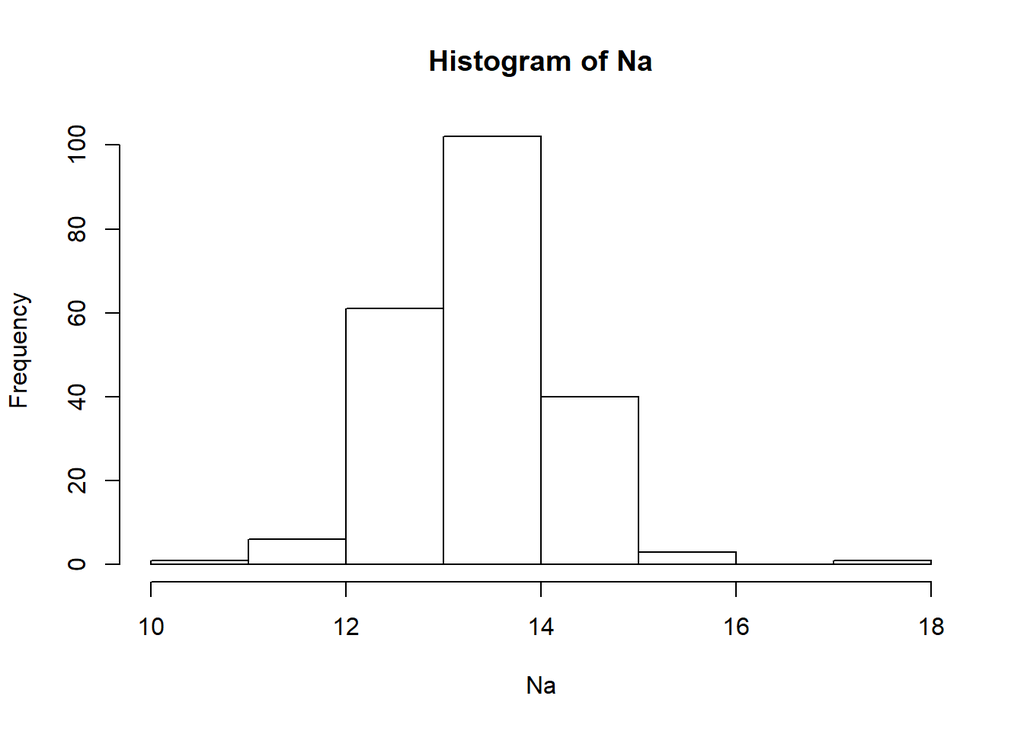

```r
hist(Na)
```

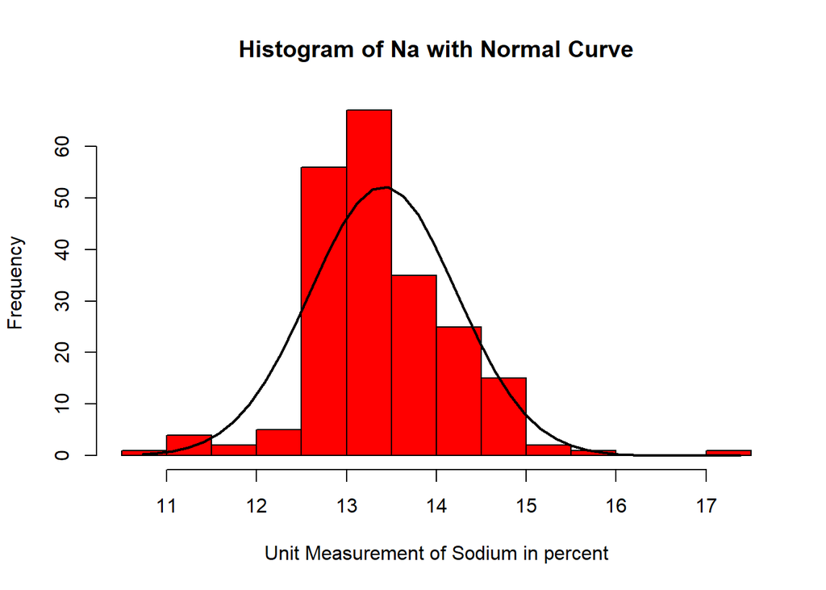

```r
# Add a Normal Curve

h<-hist(Na, breaks=10, col="red", xlab="Unit Measurement of Sodium in percent",
    main="Histogram of Na with Normal Curve")
xfit<-seq(min(Na),max(Na),length=40)
yfit<-dnorm(xfit,mean=mean(Na),sd=sd(Na))
yfit <- yfit*diff(h$mids[1:2])*length(Na)
lines(xfit, yfit, col="black",lwd=2)
```

```r
#K-NN Algorith requires normalized data as it gives accurate results when the data is scaled#
```

Q-4-5 Normalization using min-max normalization and z-score normalization